# Nonparametric Test

ChatGPT 4o

2025-01-21

## 1 起源

非参数检验（Nonparametric Test）是统计分析中的一种方法，起源于20世纪初，主要由Friedrich Riesz和Ronald Fisher等统计学家发展起来。非参数检验旨在处理数据不满足特定分布假设的情况，特别是在数据偏离正态分布、样本量较小或存在异常值时，非参数检验为研究者提供了有效的解决方案。与参数检验相比，非参数检验对数据的分布假设要求较少，因此适用于更多类型的数据分析。

## 2 原理

非参数检验的核心原理是通过对数据的排名或计数而非实际数值进行分析，以避免对数据分布的强假设。非参数检验方法不依赖于参数估计和数据分布形状，因此在数据不满足正态分布假设或存在明显异常值的情况下仍然能够提供稳健的结论。

常见的非参数检验包括：

- **Wilcoxon符号秩检验（Wilcoxon Signed-Rank Test）**：用于比较两个相关样本的中位数差异，相当于非参数版的配对t检验。
- **Mann-Whitney U检验**（Mann-Whitney U Test）：用于比较两个独立样本的中位数差异，相当于非参数版的独立样本t检验。
- **Kruskal-Wallis检验**（Kruskal-Wallis Test）：用于比较三个或更多独立样本的中位数差异，相当于非参数版的单因素方差分析（ANOVA）。
- **Friedman检验**（Friedman Test）：用于比较多个相关样本的中位数差异，相当于非参数版的重复测量方差分析。
- **卡方检验（Chi-Square Test）**：用于检验类别变量之间的独立性或拟合优度。

## 3 适用范围

非参数检验适用于以下情况：

- **数据不满足正态分布假设**：当数据明显偏离正态分布且样本量不足以满足中心极限定理时，非参数检验更为合适。
- **数据类型为顺序或类别变量**：对于不能计算均值的顺序数据或类别数据，使用非参数检验更为合适。
- **存在异常值或极端值**：非参数检验对异常值较不敏感，因此在数据中存在异常值时仍然可以提供稳健的结果。
- **样本量较小**：在样本量较小且难以进行参数估计的情况下，非参数检验是一个有效的替代方法。

## 4 应用情境

非参数检验在多个领域中有广泛的应用，例如：

- **医学和生物学**：用于比较治疗组和对照组的疗效，特别是在样本量较小或数据分布不确定时。
- **心理学和社会科学**：用于分析调查问卷中类别数据或顺序数据的组间差异。
- **教育学**：用于比较不同教学方法对学生成绩的影响，当数据不满足正态性假设时使用。
- **市场研究**：用于比较不同群体对某一产品的偏好，尤其是在数据为顺序或类别变量时。

## 5 优缺点

### 优点

- **无需分布假设**：非参数检验不需要数据满足正态分布等特定假设，因此适用性广泛。
- **对异常值鲁棒**：非参数检验对数据中的异常值较不敏感，能够提供稳健的分析结果。
- **适用于多种数据类型**：非参数检验适用于顺序数据和类别数据，适用性强。

### 缺点

- **效能较低**：与参数检验相比，非参数检验在样本量较大时统计效能较低，可能无法检测到微小的差异。
- **不能提供参数估计**：非参数检验不能提供均值、标准差等参数估计，结果的解释相对有限。
- **计算复杂性**：在某些情况下，非参数检验的计算过程较为复杂，尤其是在处理大样本数据时。

## 6 在R中的实现及结果解释

在R中，可以使用`stats`包或`coin`包来进行非参数检验，以下是一些常见的非参数检验示例，包括Mann-Whitney U检验、Wilcoxon符号秩检验、Kruskal-Wallis检验和Friedman检验。

### Mann-Whitney U检验示例

```r
# 加载必要的包（stats包是R的内置包，无需加载）

# 示例数据：生成假设的两组独立样本数据
set.seed(123)
group1 <- rnorm(20, mean = 5, sd = 1)
group2 <- rnorm(20, mean = 6, sd = 1)

# 进行Mann-Whitney U检验
mw_result <- wilcox.test(group1, group2, alternative = "two.sided")

# 输出检验结果
print(mw_result)
```

```
##
##  Wilcoxon rank sum exact test
##
## data:  group1 and group2
## W = 104, p-value = 0.008712
## alternative hypothesis: true location shift is not equal to 0
```

```r
summary(mw_result)
```

```
##             Length Class  Mode
## statistic   1      -none- numeric
## parameter   0      -none- NULL
## p.value     1      -none- numeric
## null.value  1      -none- numeric
## alternative 1      -none- character
## method      1      -none- character
## data.name   1      -none- character
```

```r
str(mw_result)
```

```
## List of 7
##  $ statistic  : Named num 104
##   ..- attr(*, "names")= chr "W"
##  $ parameter  : NULL
##  $ p.value    : num 0.00871
##  $ null.value : Named num 0
##   ..- attr(*, "names")= chr "location shift"
##  $ alternative: chr "two.sided"
##  $ method     : chr "Wilcoxon rank sum exact test"
##  $ data.name  : chr "group1 and group2"
##  - attr(*, "class")= chr "htest"
```

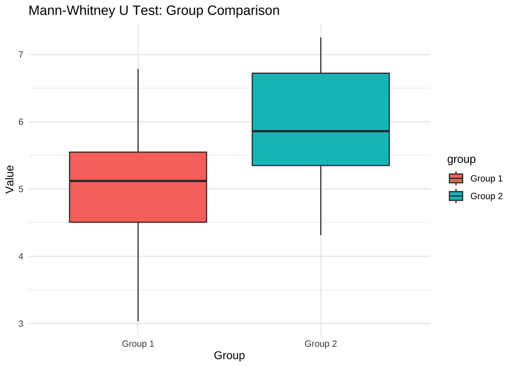

```r
# 可视化：绘制两组数据的分布箱线图
library(ggplot2)
data <- data.frame(
  group = rep(c("Group 1", "Group 2"), each = 20),
  value = c(group1, group2)
)

ggplot(data, aes(x = group, y = value, fill = group)) +
  geom_boxplot() +
  labs(title = "Mann-Whitney U Test: Group Comparison", x = "Group", y = "Value") +
  theme_minimal()
```

#### 结果解释

- **Mann-Whitney U检验结果**：通过`wilcox.test()`函数进行Mann-Whitney U检验，用于比较两组独立样本的中位数差异。输出结果包括检验统计量W值和p值。如果p值小于显著性水平（通常为0.05），则表示两组之间存在显著差异。
- **箱线图可视化**：通过箱线图展示两组数据的分布情况，直观展示中位数和数据离散程度。箱线图有助于理解两组之间的差异以及数据的分布形态。

#### 结果的可视化

通过绘制两组数据的箱线图，可以直观了解两组数据的中位数、分布范围以及数据的离散程度。

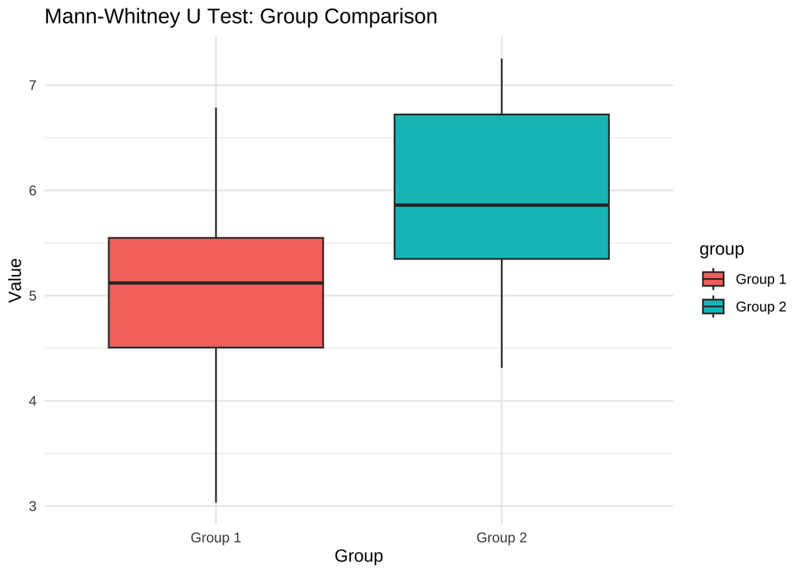

```r
# 使用ggplot2绘制两组数据的分布箱线图
library(ggplot2)
data <- data.frame(
  group = rep(c("Group 1", "Group 2"), each = 20),
  value = c(group1, group2)
)

ggplot(data, aes(x = group, y = value, fill = group)) +
  geom_boxplot() +
  labs(title = "Mann-Whitney U Test: Group Comparison", x = "Group", y = "Value") +
  theme_minimal()
```

### Wilcoxon符号秩检验示例

```r
# 示例数据：生成假设的配对样本数据
set.seed(123)
before <- rnorm(20, mean = 50, sd = 5)
after <- before + rnorm(20, mean = 2, sd = 5)

# 进行Wilcoxon符号秩检验
wilcox_result <- wilcox.test(before, after, paired = TRUE, alternative = "two.sided")

# 输出检验结果
print(wilcox_result)
```

```
##
##  Wilcoxon signed rank exact test
##
## data:  before and after
## V = 59, p-value = 0.08969
## alternative hypothesis: true location shift is not equal to 0
```

```r
summary(wilcox_result)
```

```
##             Length Class  Mode
## statistic   1      -none- numeric
## parameter   0      -none- NULL
## p.value     1      -none- numeric
## null.value  1      -none- numeric
## alternative 1      -none- character
## method      1      -none- character
## data.name   1      -none- character
```

```r
str(wilcox_result)
```

```
## List of 7
##  $ statistic  : Named num 59
##   ..- attr(*, "names")= chr "V"
##  $ parameter  : NULL
##  $ p.value    : num 0.0897
##  $ null.value : Named num 0
##   ..- attr(*, "names")= chr "location shift"
##  $ alternative: chr "two.sided"
##  $ method     : chr "Wilcoxon signed rank exact test"
##  $ data.name  : chr "before and after"
##  - attr(*, "class")= chr "htest"
```

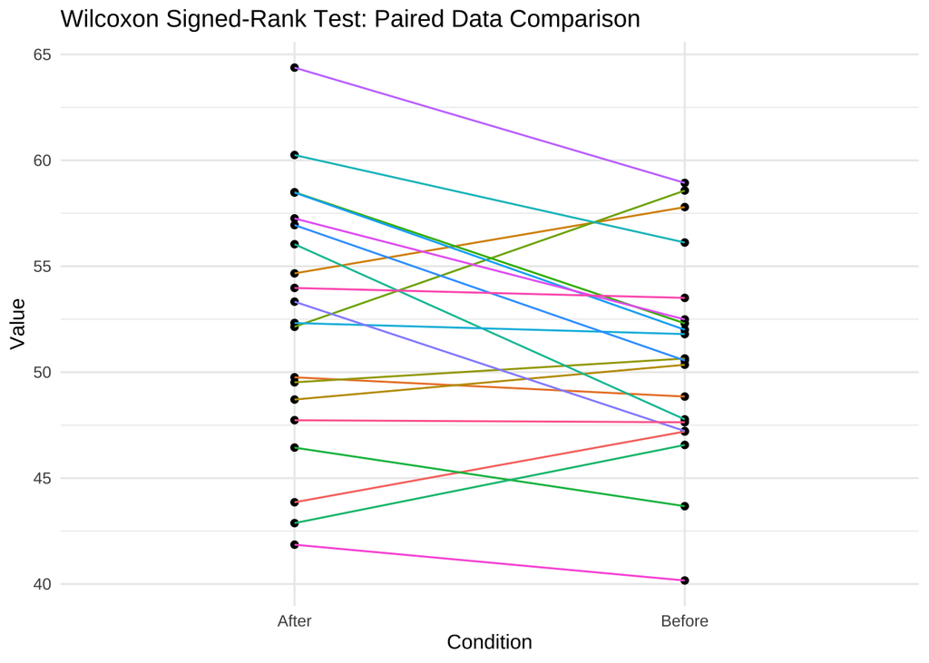

```r
# 可视化：绘制配对数据的散点图
library(ggplot2)
data_paired <- data.frame(
  condition = rep(c("Before", "After"), each = 20),
  value = c(before, after),
  id = rep(1:20, times = 2)
)

ggplot(data_paired, aes(x = condition, y = value, group = id)) +
  geom_point() +
  geom_line(aes(color = as.factor(id)), show.legend = FALSE) +
  labs(title = "Wilcoxon Signed-Rank Test: Paired Data Comparison", x = "Condition", y = "Value") +
  theme_minimal()
```

### Kruskal-Wallis检验示例

```r
# 示例数据：生成假设的三组独立样本数据
set.seed(123)
groupA <- rnorm(20, mean = 5, sd = 1)
groupB <- rnorm(20, mean = 6, sd = 1)
groupC <- rnorm(20, mean = 7, sd = 1)

# 进行Kruskal-Wallis检验
kw_result <- kruskal.test(list(groupA, groupB, groupC))

# 输出检验结果
print(kw_result)
```

```
##
##  Kruskal-Wallis rank sum test
##
## data:  list(groupA, groupB, groupC)
## Kruskal-Wallis chi-squared = 27.447, df = 2, p-value = 1.097e-06
```

```r
summary(kw_result)
```

```
##           Length Class  Mode
## statistic 1      -none- numeric
## parameter 1      -none- numeric
## p.value   1      -none- numeric
## method    1      -none- character
## data.name 1      -none- character
```

```r
str(kw_result)
```

```
## List of 5
##  $ statistic: Named num 27.4
##   ..- attr(*, "names")= chr "Kruskal-Wallis chi-squared"
##  $ parameter: Named int 2
##   ..- attr(*, "names")= chr "df"
##  $ p.value  : num 1.1e-06
##  $ method   : chr "Kruskal-Wallis rank sum test"
##  $ data.name: chr "list(groupA, groupB, groupC)"
##  - attr(*, "class")= chr "htest"
```

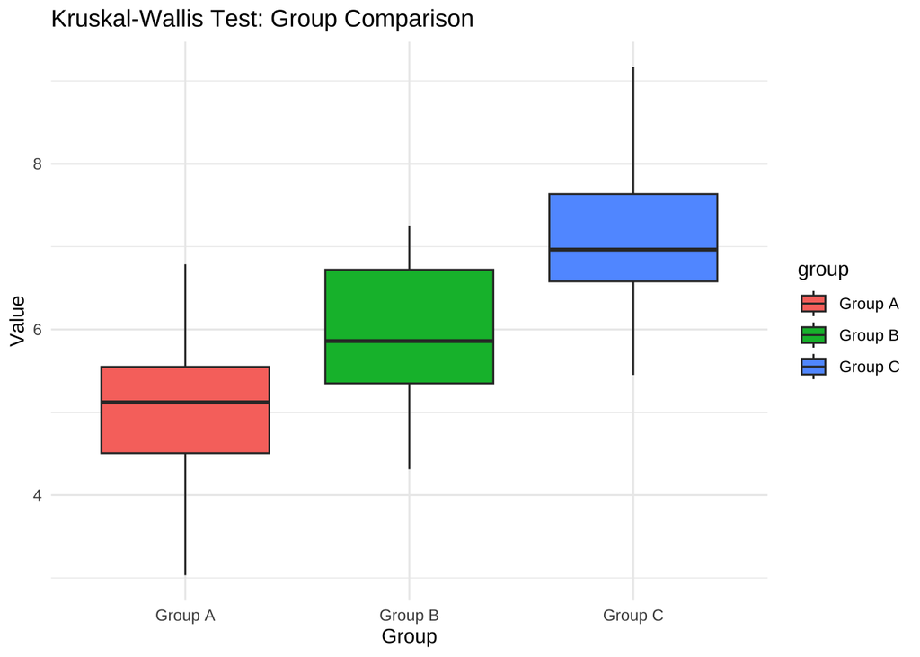

```r
# 可视化：绘制三组数据的分布箱线图
data_kw <- data.frame(
  group = rep(c("Group A", "Group B", "Group C"), each = 20),
  value = c(groupA, groupB, groupC)
)

ggplot(data_kw, aes(x = group, y = value, fill = group)) +
  geom_boxplot() +
  labs(title = "Kruskal-Wallis Test: Group Comparison", x = "Group", y = "Value") +
  theme_minimal()
```

### Friedman检验示例

```r
# 示例数据：生成假设的重复测量数据
set.seed(123)
subject <- factor(1:10)
condition1 <- rnorm(10, mean = 5, sd = 1)
condition2 <- rnorm(10, mean = 6, sd = 1)
condition3 <- rnorm(10, mean = 7, sd = 1)

# 进行Friedman检验
friedman_result <- friedman.test(y = cbind(condition1, condition2, condition3))

# 输出检验结果
print(friedman_result)
```

```
##
##  Friedman rank sum test
##
## data:  cbind(condition1, condition2, condition3)
## Friedman chi-squared = 7.4, df = 2, p-value = 0.02472
```

```r
summary(friedman_result)
```

```
##           Length Class  Mode
## statistic 1      -none- numeric
## parameter 1      -none- numeric
## p.value   1      -none- numeric
## method    1      -none- character
## data.name 1      -none- character
```

```r
str(friedman_result)
```

```
## List of 5
##  $ statistic: Named num 7.4
##   ..- attr(*, "names")= chr "Friedman chi-squared"
##  $ parameter: Named num 2
##   ..- attr(*, "names")= chr "df"
##  $ p.value  : num 0.0247
##  $ method   : chr "Friedman rank sum test"
##  $ data.name: chr "cbind(condition1, condition2, condition3)"
##  - attr(*, "class")= chr "htest"
```

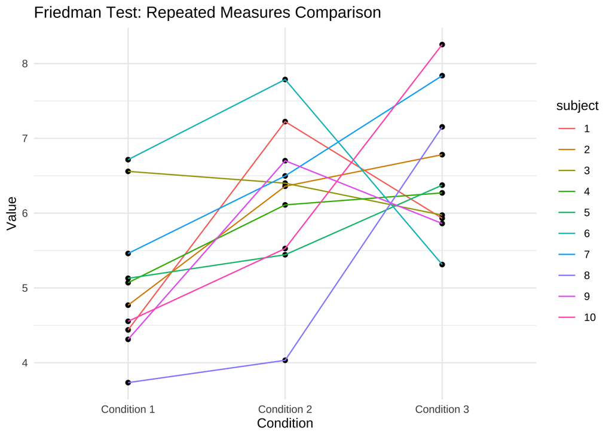

```r
# 可视化：绘制重复测量数据的线图
data_friedman <- data.frame(
  subject = rep(subject, times = 3),
  condition = rep(c("Condition 1", "Condition 2", "Condition 3"), each = 10),
  value = c(condition1, condition2, condition3)
)

ggplot(data_friedman, aes(x = condition, y = value, group = subject)) +
  geom_point() +
  geom_line(aes(color = subject)) +
  labs(title = "Friedman Test: Repeated Measures Comparison", x = "Condition", y = "Value") +
  theme_minimal()
```

## 7 小结

- 非参数检验是一种无需对数据分布做强假设的统计方法，适用于数据不满足正态分布、存在异常值或为顺序数据的情况。
- 常见的非参数检验包括Wilcoxon符号秩检验、Mann-Whitney U检验、Kruskal-Wallis检验等，适用于不同类型的研究设计。
- 具有无需分布假设、对异常值鲁棒等优点，但效能较低且不能提供参数估计。
- 可以通过R中的`stats`包等工具进行非参数检验，并结合箱线图等可视化工具直观展示组间差异。